# Exercise 1: Simple Linear Regression

### Goal and Background

The goal of this exercise is to provide hands on experience fitting a general linear model using JAGS. It is well established that temperature has a large influence on the rates of metabolic processes. Therefore, variation in environmental temperatures encountered by organisms has the potential to influence not only metabolic processes of individuals, but also population and community-level dynamics. This positive relationship between temperature and metabolism suggests that temperature and life-stage duration should be negatively correlated. As discussed in lecture, to examine if a negative relationship exists for marine organisms, O’Connor et al. (2007) compiled data from the literature describing the duration of the planktonic larval stage for 72 species that were raised over a range of water temperatures. A first step to examining the relationship between temperature and planktonic larval duration is to see if a negative relationship does in fact exist between temperature and planktonic larval duration (PLD).

### The data

The data set contains information on the phylum of the organism, the species name, the developmental feeding mode (coded **L** for lecithotrophic and **P** for planktotrophic), water temperature in degrees Celsius and planktonic larval duration in days. The data are included in the text file `PLD.txt`.

### Instructions

For this exercise the emphasis is on writing the JAGS code to fit a simple linear regression model, so all the R code for reading/manipulating/plotting data has been provided. Use the R script as a start, and turn in your assignment in the output (html, PDF, etc.) of an R Markdown file. If you would like to start from scratch and not use the R code provided, you are welcome to do that, too.

#### 1. Run script

Run all lines in the R script. Remember R is a procedural language, so you need to run (execute) all lines of code starting from the top of the script. You can run the code line-by-line or in chunks, depending on what the code is accomplishing and your familiarity with R. If you have questions about what specific lines of R code are doing, please ask.

#### 2. Data and Summary

- Read in the data and look at the structure of the data (using the `str` command or the Environment window in R studio) to make sure everything looks good and to start getting familiarized with the data set.
- There should be 214 rows of data and 5 columns.
- Summarize the data using the `summary` function.

#### 2. Exploratory Analysis

- We suspect that there is a negative relationship between PLD and temperature. Explore this graphically first. Run the code to make a quick and ugly plot of the data. We will add a fitted line to the data.
- Does the plot look linear?
- Fit a simple linear regression model of using the `lm` function in R.
- What does the model look like in proper mathematical/statistical notation?
- Examine diagnostic plots. Do things look reasonable in terms of the assumptions of normality and homoscedasticity?
- The assumption of homoscedasticity is definitely violated, so let’s look at a plot of $log_e$-transformed PLD and $log_e$-transformed temperature.
- Next, run the code to fit the log-log model using the `lm` function. Examine the diagnostic plots. Things look better, so we will stick with using $log_e$-transformed PLD and $log_e$-transformed temperature.

#### 3. Linear Regression using JAGS

- Fit the model in your above Equation using JAGS. Most of the JAGS code is provided, but *you need to fill in the likelihood and specify the priors. The likelihood includes specifying the distributional assumption for the response variable and the linear predictor*.
- To ensure that the rest of the R code runs properly, name the intercept of your model `alpha`, the slope `beta`, the precision `tau`, and the residual standard deviation `sigma`.
- Use diffuse normal priors for `alpha` and `beta` using the `dnorm` function (remember that normal distribution is parameterized in JAGS by the mean and precision $(1/\sigma^2)$, so a small precision means a large variance. Use a diffuse uniform distribution for `sigma` using the `dunif` function. You can use an upper and lower bounds for the uniform of 0 and 10, respectively.
- Add the data to your bundled data (a list), initial values are specified, and the MCMC settings are set for you; however, look them over and ask questions if you are uncertain about what they are accomplishing or if you have questions about the R code.
- Execute JAGS and fit the model.
- Examine the summary of the output. The posterior means of the parameters should be nearly identical to the estimates from the model using the `lm` function.
- Use diagnostic plots and interpret the convergence.
- Run the code to create a plot of the fitted model with uncertainty (95% credible region) around the fitted regression line. The plot should look something like Figure 1.

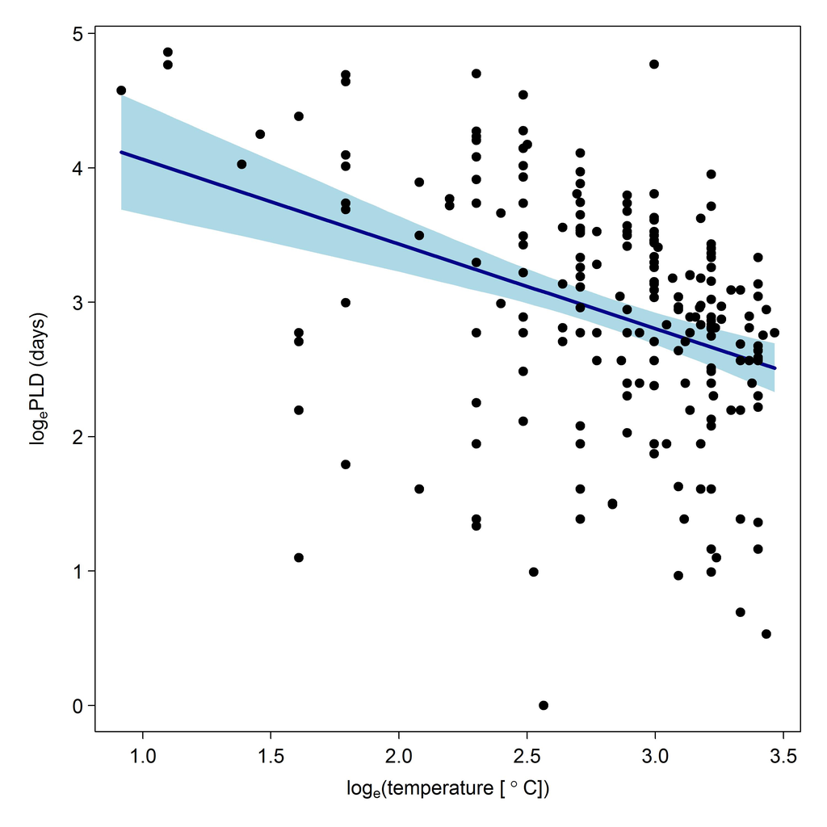

Figure 1. Plot of the relationship between PLD and temperature. Solid line is fitted regression line (posterior mean) and shaded area is a 95% credible region.

**What is due: By 5pm on Wednesday October 9th, please email me a digital version of the output of an R Markdown file that contains all the step-by-step information requested in this assignment, such that I could exactly reproduce the work. (I will likely attempt to reproduce your work, so you may want to test the reproducability with a classmate or friend before you submit.)**